# PhD Research Notebook 101317

Erich Seamon

10/4/2017

## Agricultural Commodity Loss, AOV, interactions, overall distributions

This in Notebook 101317 that analyzes commodity loss data with NO climate data. We look at qqplots to visually look for normality for commodity loss, commodity claim counts, as well as transformed loss (cube root). We then look at AOV for single interactions and look at the outputs. We then looked at a linear model with multiple factors (commodity, damage cause, county, year).

DESCRIPTION: We initially load our needed libraries, and load our CSV files of agriculture data that have been pre-wrangled.

```r
library(rpart)                      # Popular decision tree algorithm
library(rattle)                 # Fancy tree plot
library(rpart.plot)             # Enhanced tree plots
library(RColorBrewer)               # Color selection for fancy tree plot
library(party)                  # Alternative decision tree algorithm
library(partykit)               # Convert rpart object to BinaryTree
library(caret)                  # Just a data source for this script
library(mvnormtest)
# but probably one of the best R packages ever.
data(segmentationData)              # Get some data
data <- segmentationData[,-c(1,2)]
library(maptools)
#------
```

```r
#-Loading all commodities for the palouse 1989 - 2015

palouse_sumloss_allcomm <- read.csv("/waf/agmesh-scenarios/Allstates/summaries/palouse_summary_all.csv")
palouse_sumloss_allcomm2  <- aggregate(loss ~ year + damagecause + county + commodity,  palouse_sumloss_allcomm, sum)
palouse_count_allcomm2  <- aggregate(count ~ year + damagecause + county + commodity,  palouse_sumloss_allcomm, sum)

#-Loading all WHEAT claims for the palouse from 1989-2015

palouse_sumloss <- read.csv("/waf/agmesh-scenarios/Allstates/summaries/Palouse_summary_sumloss.csv")
palouse_counts <- read.csv("/waf/agmesh-scenarios/Allstates/summaries/Palouse_summary_counts.csv")
palouse_sumloss <- aggregate(loss ~ year + damagecause + county,  palouse_sumloss, sum)
palouse_counts <- aggregate(count ~ year + damagecause + county,  palouse_counts, sum)

#palouse_sumloss_drought <- subset(palouse_sumloss, damagecause == "Drought")
#qqnorm(palouse_sumloss_drought$cube_loss)
```

DESCRIPTION: Below we prepare for our qqplots.

```r
#use a cube transformation on loss for WHEAT claims

Math.cbrt <- function(x) {
  sign(x) * abs(x)^(1/3)
}

#palouse_sumloss2 <- subset(palouse_sumloss, loss > 0)

palouse_sumloss$cube_loss <- Math.cbrt(palouse_sumloss$loss)
palouse_counts$cube_counts <- Math.cbrt(palouse_counts$count)

#use a cube transformation on loss for all commodity claims

palouse_sumloss_allcomm2$cube_loss <- Math.cbrt(palouse_sumloss_allcomm2$loss)

#-use a log transform on the same WHEAT claims data

palouse_sumloss$log_loss <- log(which(!is.na(palouse_sumloss$loss)))

# - plot some qqplots to see how normal the data is
```

DESCRIPTION: Below we print out qqplots for each group we are looking at, to see if any of the response variables are somewhat normally distributed.

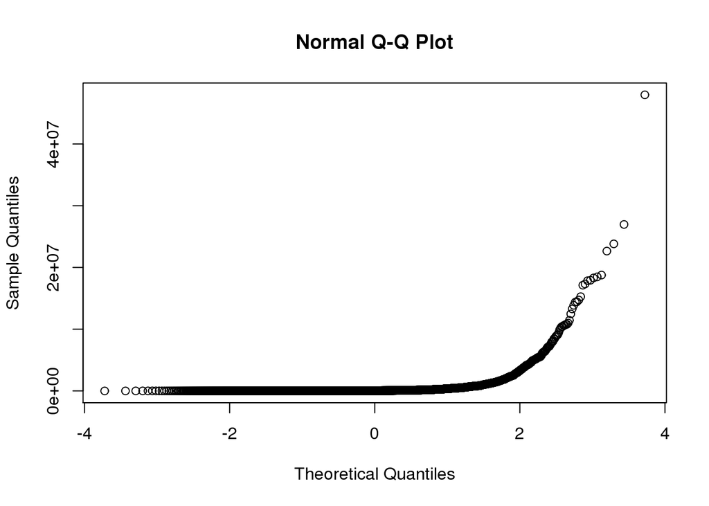

```r
qqnorm(palouse_sumloss$loss)
```

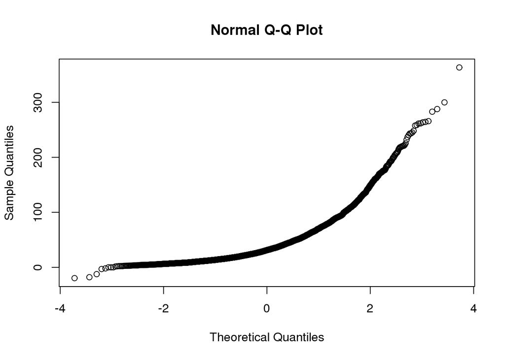

```r
qqnorm(palouse_sumloss$cube_loss)
```

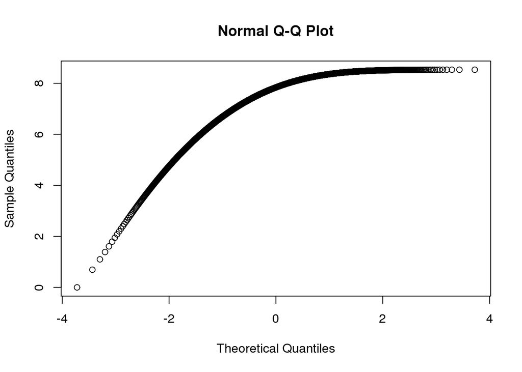

```r
qqnorm(palouse_sumloss$log_loss)
```

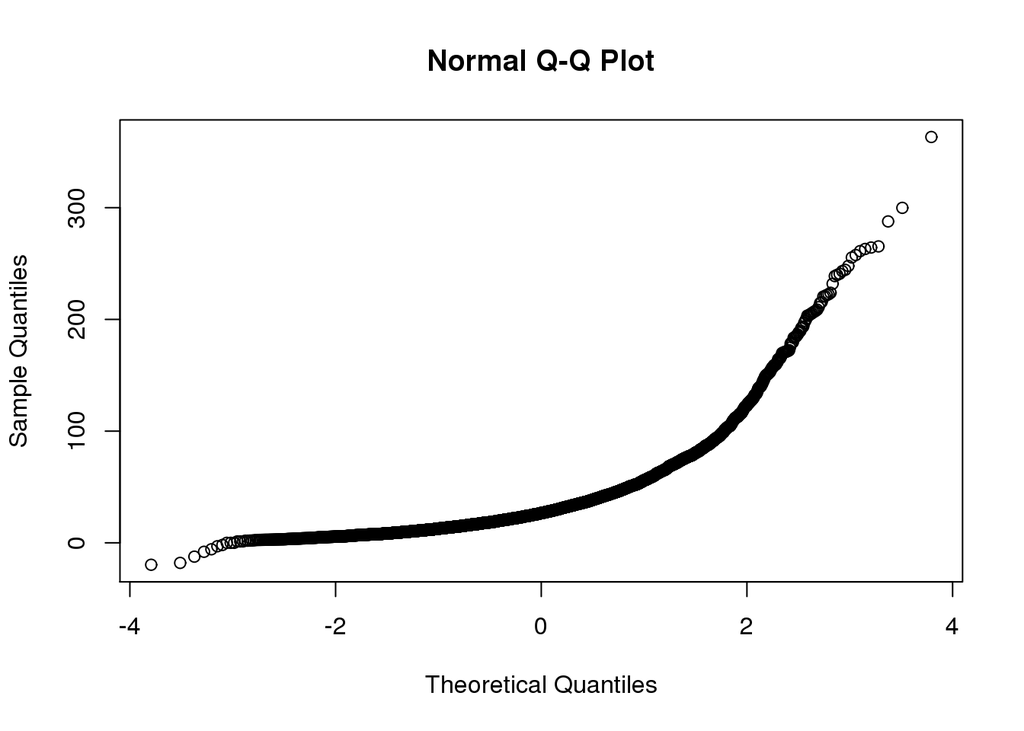

```r
qqnorm(palouse_sumloss_allcomm2$cube_loss)
```

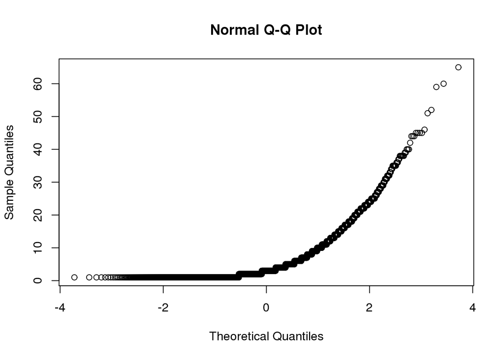

```r
qqnorm(palouse_counts$count)
```

DESCRIPTION: Below is an interaction plot of cube root loss with year and damagecause

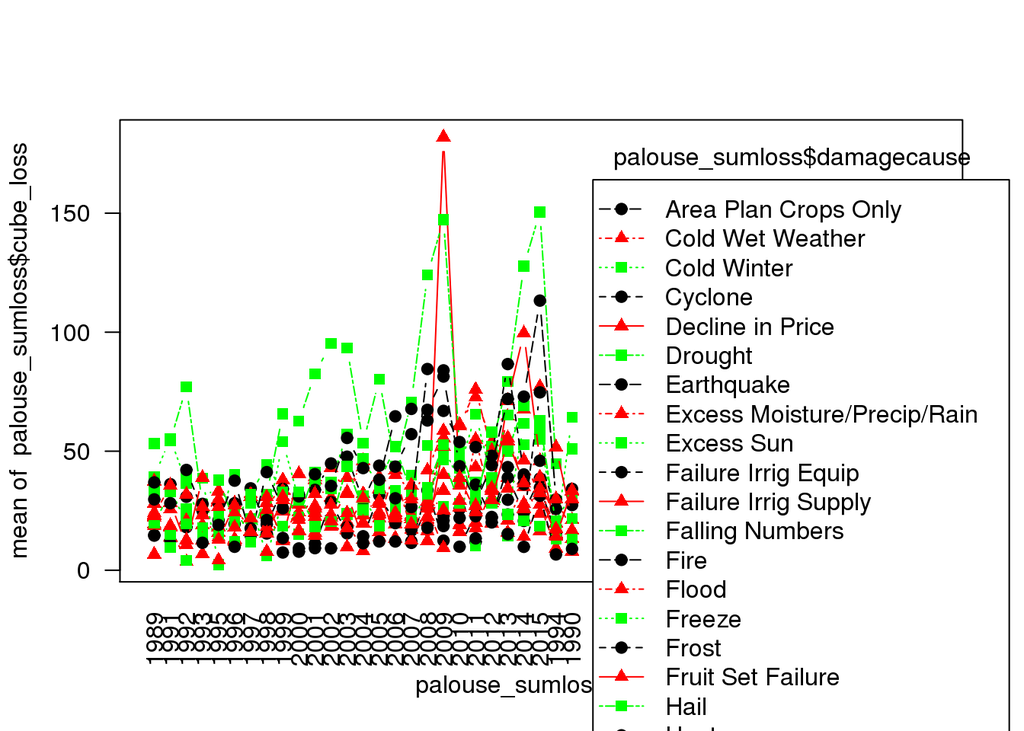

```r
#-factor counties
palouse_sumloss$county = factor(palouse_sumloss$county,
                                levels=unique(palouse_sumloss$county))
#-factor years
palouse_sumloss$year = factor(palouse_sumloss$year,
                                levels=unique(palouse_sumloss$year))

#-plot basic interaction plots for WHEAT cube root loss using year as x and damagecause as the line

interaction.plot(x.factor     = palouse_sumloss$year,
                 trace.factor = palouse_sumloss$damagecause,
                 response     = palouse_sumloss$cube_loss,
                 fun = mean,
                 las = 2,
                 type="b",
                 col=c("black","red","green"),  ### Colors for levels of trace var.
                 pch=c(19, 17, 15),             ### Symbols for levels of trace var.
                 fixed=TRUE,                    ### Order by factor order in data
                 leg.bty = "o")
```

DESCRIPTION: Below is an interaction plot of commodity counts with year and damagecause

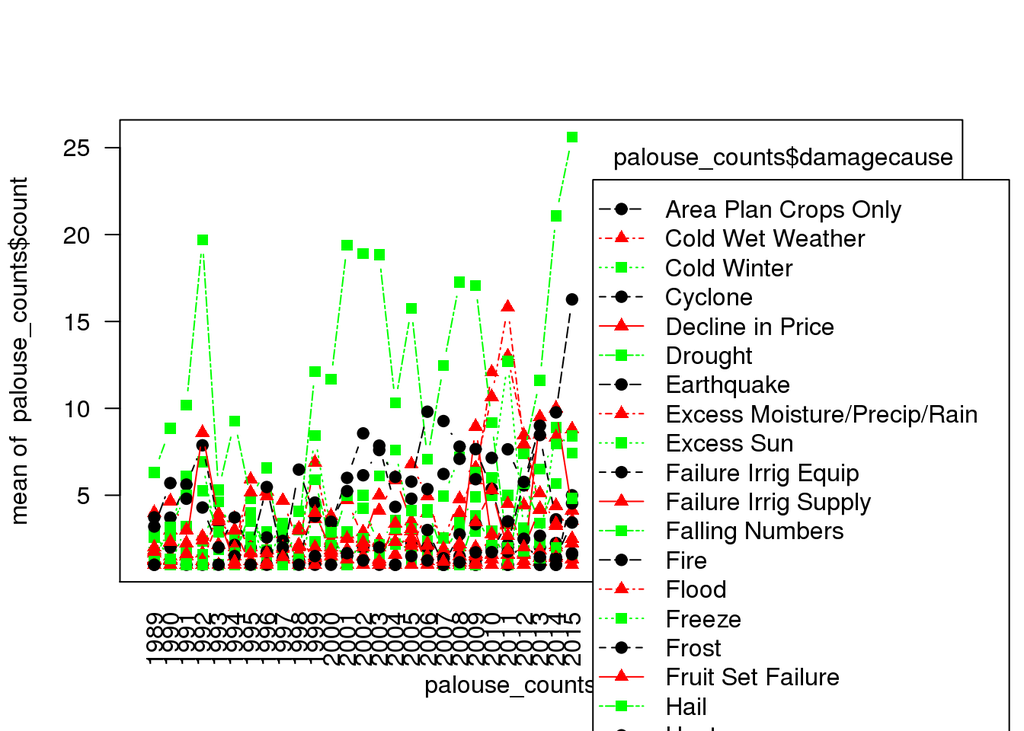

```r
interaction.plot(x.factor     = palouse_counts$year,
                 trace.factor = palouse_counts$damagecause,
                 response     = palouse_counts$count,
                 fun = mean,
                 las = 2,
                 type="b",
                 col=c("black","red","green"),  ### Colors for levels of trace var.
                 pch=c(19, 17, 15),             ### Symbols for levels of trace var.
                 fixed=TRUE,                    ### Order by factor order in data
                 leg.bty = "o")
```

DESCRIPTION: Below is an interaction plot of commodity counts with year and county

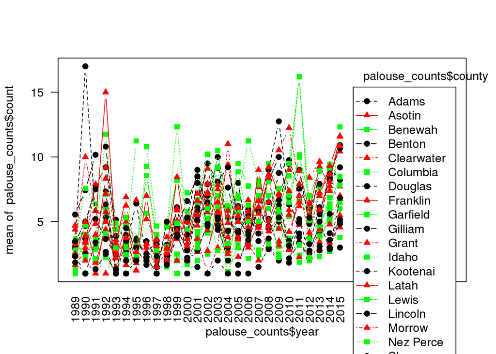

```r
interaction.plot(x.factor     = palouse_counts$year,
                 trace.factor = palouse_counts$county,
                 response     = palouse_counts$count,
                 fun = mean,
                 las = 2,
                 type="b",
                 col=c("black","red","green"),  ### Colors for levels of trace var.
                 pch=c(19, 17, 15),             ### Symbols for levels of trace var.
                 fixed=TRUE,                    ### Order by factor order in data
                 leg.bty = "o")
```

```r
bartlett.test(palouse_sumloss_allcomm2$loss, palouse_sumloss_allcomm2$county)
```

```
##
##  Bartlett test of homogeneity of variances
##
## data:  palouse_sumloss_allcomm2$loss and palouse_sumloss_allcomm2$county
## Bartlett's K-squared = 6829.2, df = 25, p-value < 2.2e-16
```

```r
bartlett.test(palouse_sumloss$loss, palouse_sumloss$county)
```

```
##
##  Bartlett test of homogeneity of variances
##
## data:  palouse_sumloss$loss and palouse_sumloss$county
## Bartlett's K-squared = 4694.6, df = 25, p-value < 2.2e-16
```

```r
bartlett.test(palouse_sumloss$loss, palouse_sumloss$year)
```

```
##
##  Bartlett test of homogeneity of variances
##
## data:  palouse_sumloss$loss and palouse_sumloss$year
## Bartlett's K-squared = 8699.1, df = 26, p-value < 2.2e-16
```

```r
#--All Bartlett tests show that the variances are not homogeneous
#--Fligner-Killeen test for homoskedasticity
fligner.test(palouse_sumloss_allcomm2$loss, palouse_sumloss_allcomm2$year)
```

```
##
##  Fligner-Killeen test of homogeneity of variances
##
## data:  palouse_sumloss_allcomm2$loss and palouse_sumloss_allcomm2$year
## Fligner-Killeen:med chi-squared = 737.49, df = 14, p-value <
## 2.2e-16
```

```r
qchisq(0.95, 25)
```

```
## [1] 37.65248
```

DESCRIPTION: performing an one way analysis of variance all all commodities, using damage cause as the factor.

```r
fit <- aov(cube_loss~damagecause, data=palouse_sumloss_allcomm2)
summary(fit) #Type I ANOVA table
```

```
##               Df  Sum Sq Mean Sq F value Pr(>F)
## damagecause   26  409734   15759   17.55 <2e-16 ***
## Residuals   6696 6013420     898
## ---
## Signif. codes:  0 '***' 0.001 '**' 0.01 '*' 0.05 '.' 0.1 ' ' 1
```

```r
drop1(fit,~.,test="F") # type III SS and Ftests
```

```
## Single term deletions
##
## Model:
## cube_loss ~ damagecause
##             Df Sum of Sq     RSS   AIC F value    Pr(>F)
## <none>                   6013420 45745
## damagecause 26    409734 6423154 46136  17.548 < 2.2e-16 ***
## ---
## Signif. codes:  0 '***' 0.001 '**' 0.01 '*' 0.05 '.' 0.1 ' ' 1
```

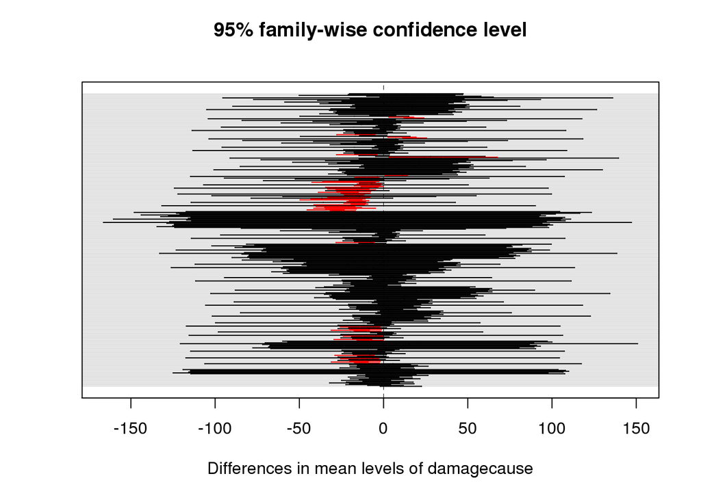

```r
library(broom)
library(magrittr)

#--ad hoc test
tuk <- TukeyHSD(fit)

psig=as.numeric(apply(tuk$`damagecause`[,2:3],1,prod)>=0)+1
plot(tuk,col=psig,yaxt="n")
```

DESCRIPTION: A table of all the combinations indicated above in red (those with a p-value less than .05)

```r
tuk2 <- as.data.frame(tidy(tuk))

#-listing combos where the mean differences in damage causes are significant
#Damage causes coming to forefront include: Drought and Decline in Price

tuk3 <- subset(tuk2, adj.p.value < .05)

tuk3
```

```
##            term                                   comparison   estimate
## 29  damagecause            Decline in Price-Cold Wet Weather  10.457743
## 30  damagecause                     Drought-Cold Wet Weather  18.007295
## 50  damagecause                    Wildlife-Cold Wet Weather -16.413608
## 53  damagecause                 Decline in Price-Cold Winter  10.962402
## 54  damagecause                          Drought-Cold Winter  18.511954
## 74  damagecause                         Wildlife-Cold Winter -15.908949
## 77  damagecause                              Drought-Cyclone  35.362128
## 99  damagecause                     Drought-Decline in Price   7.549552
## 101 damagecause Excess Moisture/Precip/Rain-Decline in Price  -9.974091
## 106 damagecause                        Fire-Decline in Price -19.466745
## 107 damagecause                       Flood-Decline in Price -23.716239
## 109 damagecause                       Frost-Decline in Price  -8.642408
## 111 damagecause                        Hail-Decline in Price  -9.612627
## 112 damagecause                        Heat-Decline in Price  -6.721832
```

[output cut: 83 more lines]

```r
fit <- aov(cube_loss~damagecause + county + year, data=palouse_sumloss)
summary(fit) #Type I ANOVA table
```

```
##               Df  Sum Sq Mean Sq F value Pr(>F)
## damagecause   28 1130158   40363   48.45 <2e-16 ***
## county        25  488294   19532   23.44 <2e-16 ***
## year          26  980629   37716   45.27 <2e-16 ***
## Residuals   4995 4161448     833
## ---
## Signif. codes:  0 '***' 0.001 '**' 0.01 '*' 0.05 '.' 0.1 ' ' 1
```

```r
drop1(fit,~.,test="F") # type III SS and Ftests
```

```
## Single term deletions
##
## Model:
## cube_loss ~ damagecause + county + year
##             Df Sum of Sq     RSS   AIC F value    Pr(>F)
## <none>                   4161448 34210
## damagecause 28   1357185 5518633 35586  58.180 < 2.2e-16 ***
## county      25    619742 4781189 34864  29.755 < 2.2e-16 ***
## year        26    980629 5142076 35231  45.271 < 2.2e-16 ***
## ---
## Signif. codes:  0 '***' 0.001 '**' 0.01 '*' 0.05 '.' 0.1 ' ' 1
```

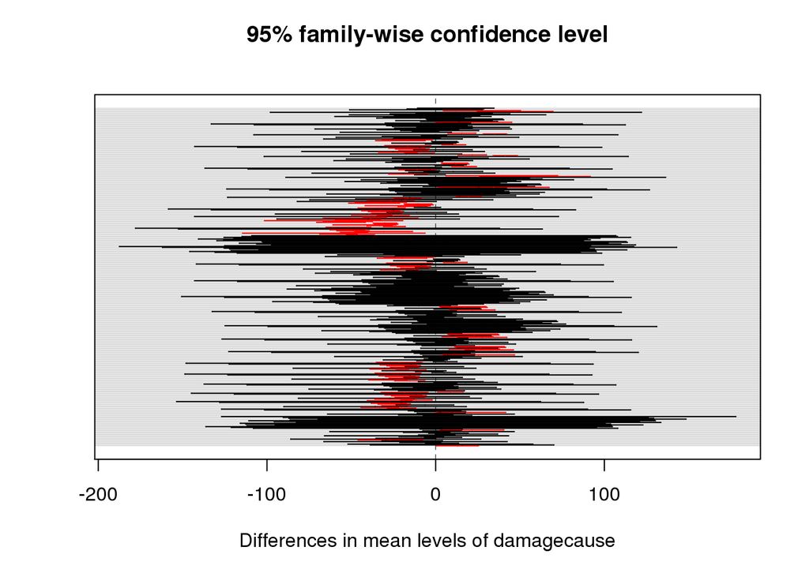

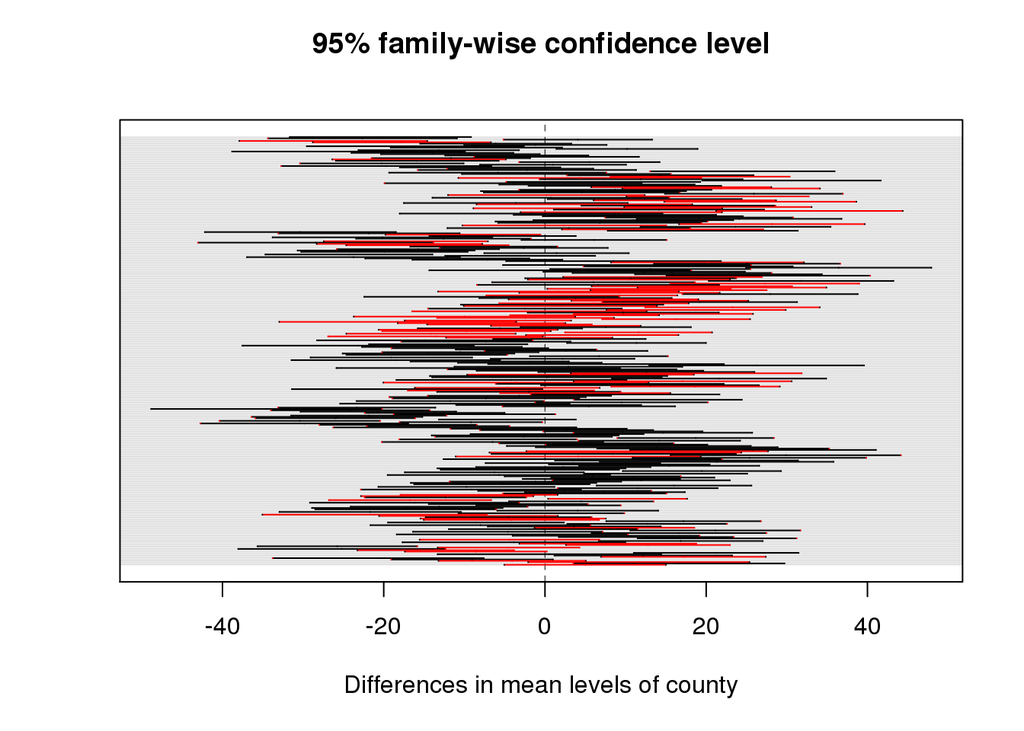

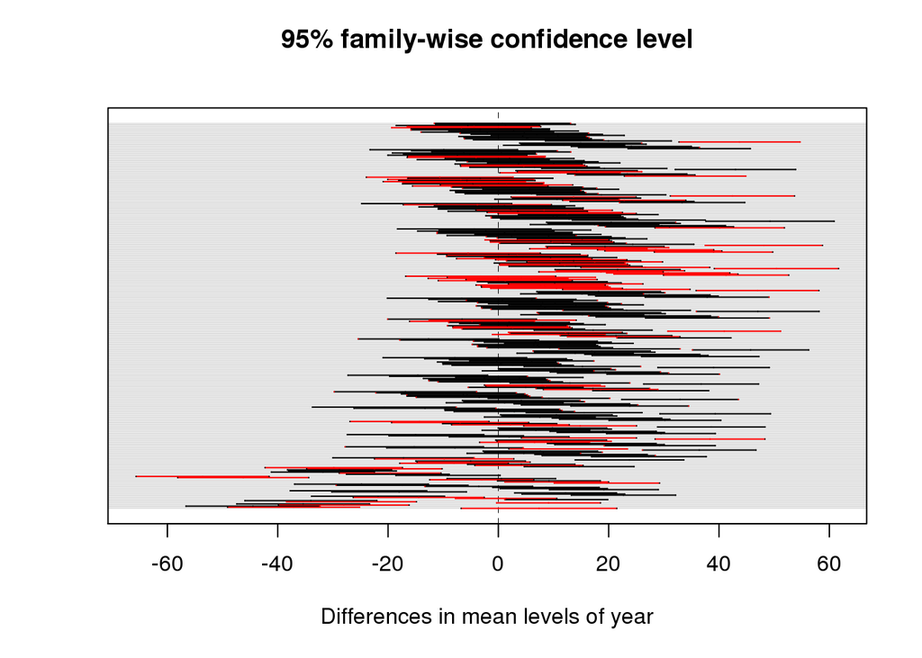

```r
#plot(fit)

library(broom)
library(magrittr)
#--ad hoc test

tukk <- TukeyHSD(fit)

psig=as.numeric(apply(tukk$`damagecause`[,2:3],1,prod)>=0)+1
plot(tukk,col=psig,yaxt="n")
```

DESCRIPTION: Table of significant combinations

```r
tukk2 <- as.data.frame(tidy(tukk))

#-listing combos where the mean differences in damage causes are significant
#Damage causes coming to forefront include: Drought and Decline in Price
tukk3 <- subset(tukk2, adj.p.value < .05)

tukk3
```

```
##             term                                              comparison
## 4    damagecause                   Decline in Price-Area Plan Crops Only
## 5    damagecause                            Drought-Area Plan Crops Only
## 18   damagecause                               Heat-Area Plan Crops Only
## 31   damagecause                       Decline in Price-Cold Wet Weather
## 32   damagecause                                Drought-Cold Wet Weather
## 39   damagecause                                   Fire-Cold Wet Weather
## 40   damagecause                                  Flood-Cold Wet Weather
## 45   damagecause                                   Heat-Cold Wet Weather
## 46   damagecause                               Hot Wind-Cold Wet Weather
## 49   damagecause                                Insects-Cold Wet Weather
## 50   damagecause            Other (Snow-Lightning-Etc.)-Cold Wet Weather
## 52   damagecause                          Plant Disease-Cold Wet Weather
## 54   damagecause                               Wildlife-Cold Wet Weather
## 55   damagecause                       Wind/Excess Wind-Cold Wet Weather
```

[output cut: 841 more lines]

DESCRIPTION: performing an one way analysis of variance on only WHEAT claims in the PNW, using counts, with damage cause as the factor. We then produce a barplot of the ranges of CI for each combination.

```r
#--performing an single interaction aov for loss transformed by a cube root function
#--by damagecuase.  This is for ONLY WHEAT counts

fit <- aov(count~damagecause, data=palouse_counts)
summary(fit) #Type I ANOVA table
```

```
##               Df Sum Sq Mean Sq F value Pr(>F)
## damagecause   28  49861  1780.7   57.15 <2e-16 ***
## Residuals   5046 157241    31.2
## ---
## Signif. codes:  0 '***' 0.001 '**' 0.01 '*' 0.05 '.' 0.1 ' ' 1
```

```r
drop1(fit,~.,test="F") # type III SS and Ftests
```

```
## Single term deletions
##
## Model:
## count ~ damagecause
##             Df Sum of Sq    RSS   AIC F value    Pr(>F)
## <none>                   157241 17483
## damagecause 28     49861 207101 18825  57.146 < 2.2e-16 ***
## ---
## Signif. codes:  0 '***' 0.001 '**' 0.01 '*' 0.05 '.' 0.1 ' ' 1
```

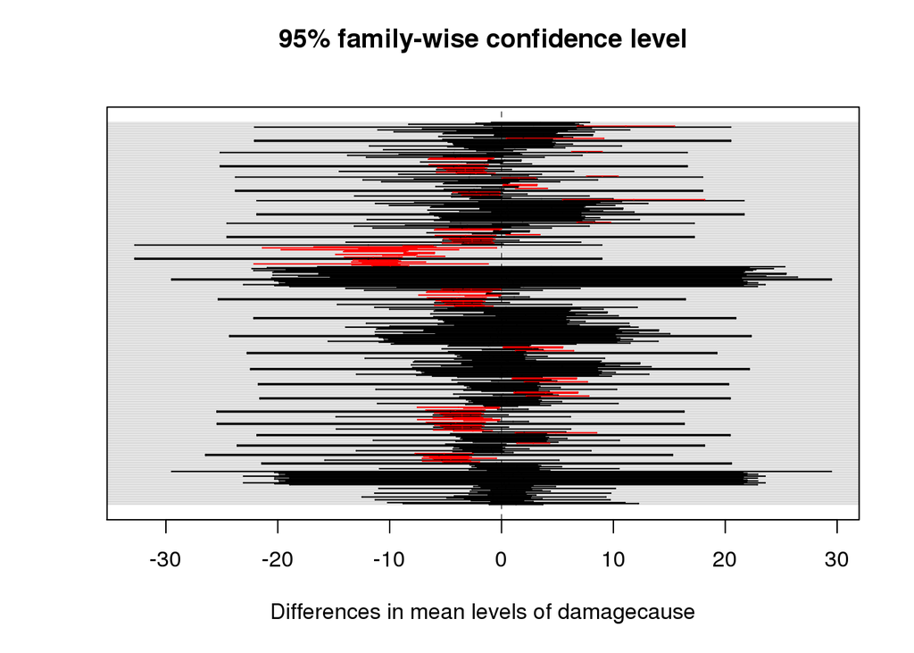

```r
#plot(fit)

library(broom)
library(magrittr)
#--ad hoc test

tukk <- TukeyHSD(fit)

psig=as.numeric(apply(tukk$`damagecause`[,2:3],1,prod)>=0)+1
plot(tukk,col=psig,yaxt="n")
```

DESCRIPTION: Table of significant combinations

```r
tukk2 <- as.data.frame(tidy(tukk))
#subset(tukk2, adj.p.value < .05)

#-listing combos where the mean differences in damage causes are significant
#Damage causes coming to forefront include: Drought and Decline in Price
tukk3 <- subset(tukk2, adj.p.value < .05)

tukk3
```

```
##            term                                              comparison
## 5   damagecause                            Drought-Area Plan Crops Only
## 18  damagecause                               Heat-Area Plan Crops Only
## 32  damagecause                                Drought-Cold Wet Weather
## 39  damagecause                                   Fire-Cold Wet Weather
## 40  damagecause                                  Flood-Cold Wet Weather
## 46  damagecause                               Hot Wind-Cold Wet Weather
## 49  damagecause                                Insects-Cold Wet Weather
## 50  damagecause            Other (Snow-Lightning-Etc.)-Cold Wet Weather
## 52  damagecause                          Plant Disease-Cold Wet Weather
## 54  damagecause                               Wildlife-Cold Wet Weather
## 55  damagecause                       Wind/Excess Wind-Cold Wet Weather
## 58  damagecause                                     Drought-Cold Winter
## 60  damagecause                 Excess Moisture/Precip/Rain-Cold Winter
## 67  damagecause                                      Freeze-Cold Winter
```

[output cut: 173 more lines]

DESCRIPTION: performing an one way analysis of variance on all commidity claims in the Palouse region, using cube root loss, with commodity as the factor. We then produce a barplot of the ranges of CI for each combination.

```r
#--performing an single interaction aov for loss transformed by a cube root function
#--by commodity  This is for ALL commodities

fit <- aov(cube_loss~commodity, data=palouse_sumloss_allcomm2)
summary(fit) #Type I ANOVA table
```

```
##               Df  Sum Sq Mean Sq F value Pr(>F)
## commodity     30  647249   21575      25 <2e-16 ***
## Residuals   6692 5775905     863
## ---
## Signif. codes:  0 '***' 0.001 '**' 0.01 '*' 0.05 '.' 0.1 ' ' 1
```

```r
drop1(fit,~.,test="F") # type III SS and Ftests
```

```
## Single term deletions
##
## Model:
## cube_loss ~ commodity
##           Df Sum of Sq     RSS   AIC F value    Pr(>F)
## <none>                 5775905 45482
## commodity 30    647249 6423154 46136  24.997 < 2.2e-16 ***
## ---
## Signif. codes:  0 '***' 0.001 '**' 0.01 '*' 0.05 '.' 0.1 ' ' 1
```

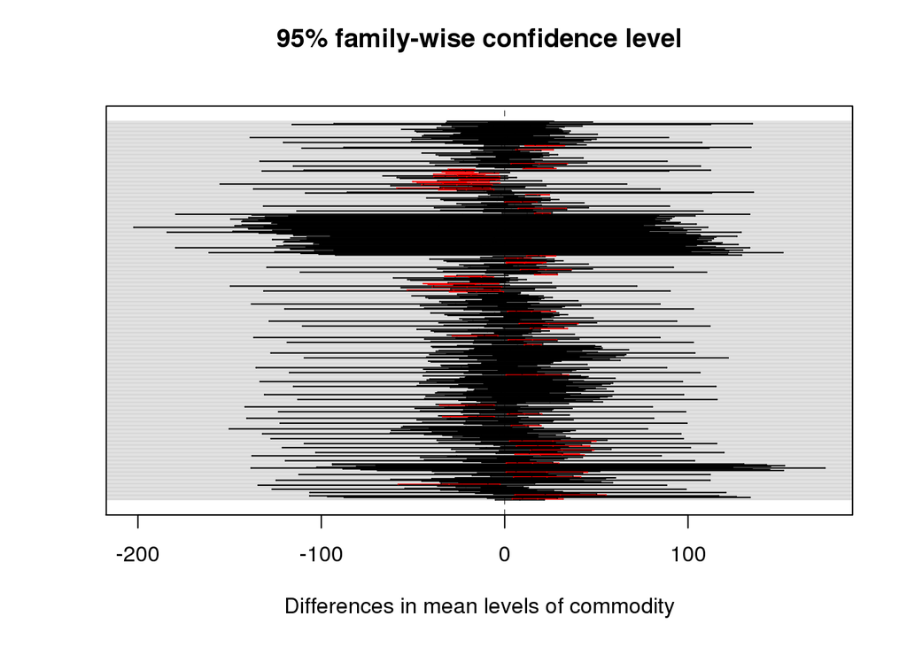

```r
library(broom)
library(magrittr)
#--ad hoc test

tukk <- TukeyHSD(fit)

psig=as.numeric(apply(tukk$`commodity`[,2:3],1,prod)>=0)+1
plot(tukk,col=psig,yaxt="n")
```

DESCRIPTION: Table of significant combinations

```r
tukk2 <- as.data.frame(tidy(tukk))

#-listing combos where the mean differences in damage causes are significant
#Damage causes coming to forefront include: Drought and Decline in Price
tukk3 <- subset(tukk2, adj.p.value < .05)

tukk3
```

```
##          term               comparison   estimate     conf.low   conf.high
## 31  commodity   APPLES-All Other Crops  21.879255  11.15360398  32.6049060
## 36  commodity CHERRIES-All Other Crops  16.339782   6.13857471  26.5409884
## 53  commodity POTATOES-All Other Crops  18.852985   3.52147955  34.1844901
## 59  commodity    WHEAT-All Other Crops  18.972517   9.99110750  27.9539256
## 60  commodity            BARLEY-APPLES -23.513614 -30.74854127 -16.2786873
## 63  commodity            CANOLA-APPLES -25.474846 -34.01898904 -16.9307036
## 65  commodity              CORN-APPLES -17.622337 -31.92081414  -3.3238590
## 66  commodity         DRY BEANS-APPLES -27.005685 -38.70787260 -15.3034978
## 67  commodity          DRY PEAS-APPLES -18.265278 -25.72216251 -10.8083938
## 69  commodity    FRESH APRICOTS-APPLES -20.694982 -38.68740614  -2.7025583
## 72  commodity            GRAPES-APPLES -13.810188 -24.84283986  -2.7775356
## 73  commodity        GREEN PEAS-APPLES -14.625167 -24.65103389  -4.5992999
## 75  commodity           MUSTARD-APPLES -29.296439 -50.12784125  -8.4650376
## 76  commodity              OATS-APPLES -34.373493 -47.66111663 -21.0858696
```

[output cut: 101 more lines]

```r
#--performing an single interaction aov for loss transformed by a cube root function
#--by year  This is for ALL commodities

fit <- aov(loss~county, data=palouse_sumloss_allcomm2)
summary(fit) #Type I ANOVA table
```

```
##               Df    Sum Sq   Mean Sq F value   Pr(>F)
## county        25 1.257e+14 5.030e+12   3.253 8.01e-08 ***
## Residuals   6697 1.035e+16 1.546e+12
## ---
## Signif. codes:  0 '***' 0.001 '**' 0.01 '*' 0.05 '.' 0.1 ' ' 1
```

```r
drop1(fit,~.,test="F") # type III SS and Ftests
```

```
## Single term deletions
##
## Model:
## loss ~ county
##        Df  Sum of Sq        RSS    AIC F value    Pr(>F)
## <none>               1.0355e+16 188719
## county 25 1.2575e+14 1.0480e+16 188750  3.2531 8.014e-08 ***
## ---
## Signif. codes:  0 '***' 0.001 '**' 0.01 '*' 0.05 '.' 0.1 ' ' 1
```

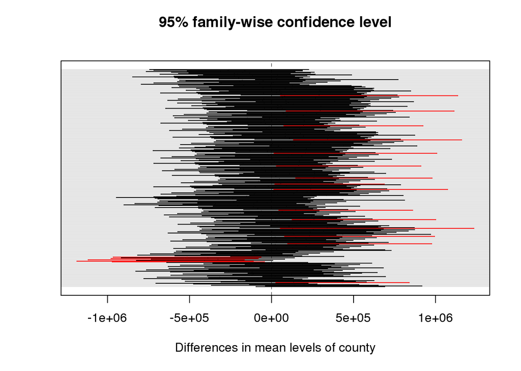

```r
library(broom)
library(magrittr)
#--ad hoc test

tukk <- TukeyHSD(fit)

psig=as.numeric(apply(tukk$`county`[,2:3],1,prod)>=0)+1
plot(tukk,col=psig,yaxt="n")
```

DESCRIPTION: Table of significant combinations

```r
tukk2 <- as.data.frame(tidy(tukk))

#-listing combos where the mean differences in damage causes are significant
#Damage causes coming to forefront include: Drought and Decline in Price
tukk3 <- subset(tukk2, adj.p.value < .05)

tukk3
```

```
##       term        comparison  estimate    conf.low  conf.high  adj.p.value
## 40  county     Morrow-Asotin  594997.1    54722.31 1135271.80 0.0129192486
## 63  county    Morrow-Benewah  601489.2    89906.43 1113071.92 0.0042165823
## 85  county     Morrow-Benton  499576.6    75511.03  923642.23 0.0040653791
## 106 county Morrow-Clearwater  646915.5   134430.49 1159400.60 0.0010166460
## 126 county   Morrow-Columbia  511611.9    15400.40 1007823.44 0.0337655609
## 145 county    Morrow-Douglas  470139.5    29617.84  910661.25 0.0208329514
## 163 county   Morrow-Franklin  563146.3   147280.47  979012.07 0.0001970823
## 172 county  Whitman-Franklin  353941.2    20192.97  687689.47 0.0228352140
## 180 county   Morrow-Garfield  543944.1    14344.93 1073543.37 0.0355351106
## 211 county      Morrow-Grant  452631.1    44544.67  860717.48 0.0115324355
## 225 county      Morrow-Idaho  563663.2   125789.66 1001536.79 0.0006594060
## 238 county   Morrow-Kootenai  643750.7    53701.45 1233799.90 0.0149577091
## 250 county      Morrow-Latah  536736.1    79307.10  994165.18 0.0043759596
## 261 county      Morrow-Lewis  537552.5    98638.86  976466.09 0.0019141618
## 281 county  Nez Perce-Morrow -514833.4  -965383.50  -64283.34 0.0070187960
## 283 county    Spokane-Morrow -529658.6  -978545.46  -80771.66 0.0039471347
## 285 county      Union-Morrow -641981.6 -1118135.83 -165827.41 0.0002198005
## 287 county    Wallowa-Morrow -648985.7 -1186775.36 -111196.09 0.0025693403
## 288 county      Wasco-Morrow -507021.0  -971038.31  -43003.72 0.0146087105
## 319 county     Whitman-Union  432776.6    26369.92  839183.22 0.0215129277
```

```r
fit_c = lm(formula = palouse_sumloss_allcomm2$loss ~ palouse_sumloss_allcomm2$county)
anova(fit_c)
```

```
## Analysis of Variance Table
##
## Response: palouse_sumloss_allcomm2$loss
##                                   Df     Sum Sq    Mean Sq F value
## palouse_sumloss_allcomm2$county   25 1.2575e+14 5.0299e+12  3.2531
## Residuals                       6697 1.0355e+16 1.5462e+12
##                                    Pr(>F)
## palouse_sumloss_allcomm2$county 8.014e-08 ***
## Residuals
## ---
## Signif. codes:  0 '***' 0.001 '**' 0.01 '*' 0.05 '.' 0.1 ' ' 1
```

```r
fit_d = lm(formula = palouse_sumloss_allcomm2$loss ~ palouse_sumloss_allcomm2$damagecause)
anova(fit_d)
```

```
## Analysis of Variance Table
##
## Response: palouse_sumloss_allcomm2$loss
##                                        Df     Sum Sq    Mean Sq F value
## palouse_sumloss_allcomm2$damagecause   26 3.7654e+14 1.4482e+13  9.5975
## Residuals                            6696 1.0104e+16 1.5090e+12
##                                         Pr(>F)
## palouse_sumloss_allcomm2$damagecause < 2.2e-16 ***
## Residuals
## ---
## Signif. codes:  0 '***' 0.001 '**' 0.01 '*' 0.05 '.' 0.1 ' ' 1
```

```r
fit_co = lm(formula = palouse_sumloss_allcomm2$loss ~ palouse_sumloss_allcomm2$commodity)
anova(fit_co)
```

```
## Analysis of Variance Table
##
## Response: palouse_sumloss_allcomm2$loss
##                                      Df     Sum Sq    Mean Sq F value
## palouse_sumloss_allcomm2$commodity   30 2.4844e+14 8.2813e+12  5.4161
## Residuals                          6692 1.0232e+16 1.5290e+12
##                                       Pr(>F)
## palouse_sumloss_allcomm2$commodity < 2.2e-16 ***
## Residuals
## ---
## Signif. codes:  0 '***' 0.001 '**' 0.01 '*' 0.05 '.' 0.1 ' ' 1
```

```r
fit_y = lm(formula = palouse_sumloss_allcomm2$loss ~ factor(palouse_sumloss_allcomm2$year))
anova(fit_y)
```

```
## Analysis of Variance Table
##
## Response: palouse_sumloss_allcomm2$loss
##                                         Df     Sum Sq    Mean Sq F value
## factor(palouse_sumloss_allcomm2$year)   14 2.9105e+14 2.0789e+13  13.686
## Residuals                             6708 1.0189e+16 1.5190e+12
##                                          Pr(>F)
## factor(palouse_sumloss_allcomm2$year) < 2.2e-16 ***
## Residuals
## ---
## Signif. codes:  0 '***' 0.001 '**' 0.01 '*' 0.05 '.' 0.1 ' ' 1
```

```r
all1 <- anova(lm(loss ~ county + damagecause + year, data = palouse_sumloss))

all_lm1 <- lm(loss ~ county + damagecause + year, data = palouse_sumloss)

palouse_sumloss_allcomm2$year <- factor(palouse_sumloss_allcomm2$year)

all2 <- anova(lm(loss ~ commodity + county + damagecause + year + commodity:damagecause, data = palouse_sumloss_allcomm2))

all_lm2 <- lm(loss ~ commodity + county + damagecause + year + commodity:damagecause, data = palouse_sumloss_allcomm2)
```

```r
#--ad hoc tukey for multiple
#-Post-hoc testing with lsmeans
#-Because the main effects were significant, we will want to perform post-hoc mean separation tests
#-for each main effect factor variable.

library(lsmeans)
lsmeans(all_lm1,
        pairwise ~ county,
        adjust="tukey")
```

```
## $lsmeans
##  county           lsmean       SE   df    lower.CL   upper.CL
##  Adams        199483.273 129029.8 4995  -53471.692  452438.24
##  Asotin      -320012.587 158857.6 4995 -631443.244   -8581.93
##  Benewah     -401267.713 165246.2 4995 -725222.716  -77312.71
##  Benton        98177.227 128129.1 4995 -153011.989  349366.44
##  Clearwater  -385783.539 164173.5 4995 -707635.579  -63931.50
##  Columbia    -199227.031 155594.7 4995 -504260.947  105806.89
##  Douglas        4631.058 133525.4 4995 -257137.279  266399.39
##  Franklin      10068.180 126663.4 4995 -238247.616  258383.98
##  Garfield    -408384.660 187869.3 4995 -776690.884  -40078.44
##  Gilliam       46373.182 150317.7 4995 -248315.490  341061.85
##  Grant        325981.669 125953.3 4995   79057.813  572905.53
##  Idaho       -108865.584 142152.0 4995 -387545.997  169814.83
##  Kootenai    -581050.158 200174.5 4995 -973479.998 -188620.32
##  Latah       -151789.378 143358.2 4995 -432834.375  129255.62
##  Lewis       -104779.303 140627.7 4995 -380471.380  170912.77
##  Lincoln      253209.123 126873.3 4995    4481.751  501936.50
##  Morrow       446570.422 145114.2 4995  162082.931  731057.91
##  Nez Perce    -66709.311 138497.9 4995 -338226.062  204807.44
##  Sherman      -85871.035 151755.8 4995 -383379.099  211637.03
##  Spokane     -186180.232 143580.9 4995 -467661.809   95301.34
##  Umatilla     432449.395 125088.3 4995  187221.340  677677.45
##  Union       -304270.594 142951.7 4995 -584518.653  -24022.53
##  Walla Walla  218282.511 129479.6 4995  -35554.266  472119.29
##  Wallowa     -448767.399 182164.2 4995 -805889.157  -91645.64
##  Wasco        -84911.701 141645.8 4995 -362599.639  192776.24
##  Whitman      369096.329 129518.2 4995  115183.716  623008.94
##
## Results are averaged over the levels of: damagecause, year
## Confidence level used: 0.95
##
## $contrasts
##  contrast                      estimate       SE   df t.ratio p.value
##  Adams - Asotin             519495.8594 150728.2 4995   3.447  0.1043
##  Adams - Benewah            600750.9857 157156.9 4995   3.823  0.0305
##  Adams - Benton             101306.0451 123586.0 4995   0.820  1.0000
##  Adams - Clearwater         585266.8117 156239.9 4995   3.746  0.0399
##  Adams - Columbia           398710.3036 147928.7 4995   2.695  0.5602
##  Adams - Douglas            194852.2150 125241.7 4995   1.556  0.9987
```

[output cut: 307 more lines]

```
##  Umatilla - Wasco           517361.0959 130134.7 4995   3.976  0.0174
##  Umatilla - Whitman          63353.0654 117793.9 4995   0.538  1.0000
##  Union - Walla Walla       -522553.1045 137589.5 4995  -3.798  0.0333
##  Union - Wallowa            144496.8050 185919.9 4995   0.777  1.0000
##  Union - Wasco             -219358.8924 147868.4 4995  -1.483  0.9994
##  Union - Whitman           -673366.9229 137750.8 4995  -4.888  0.0003
##  Walla Walla - Wallowa      667049.9095 176068.1 4995   3.789  0.0344
##  Walla Walla - Wasco        303194.2121 134253.7 4995   2.258  0.8687
##  Walla Walla - Whitman     -150813.8184 122206.1 4995  -1.234  1.0000
##  Wallowa - Wasco           -363855.6974 183863.3 4995  -1.979  0.9653
##  Wallowa - Whitman         -817863.7279 176355.0 4995  -4.638  0.0011
##  Wasco - Whitman           -454008.0305 134585.9 4995  -3.373  0.1290
##
## Results are averaged over the levels of: damagecause, year
## P value adjustment: tukey method for comparing a family of 26 estimates
```

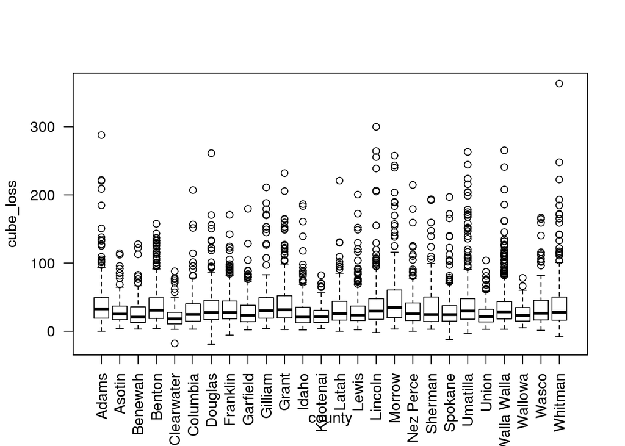

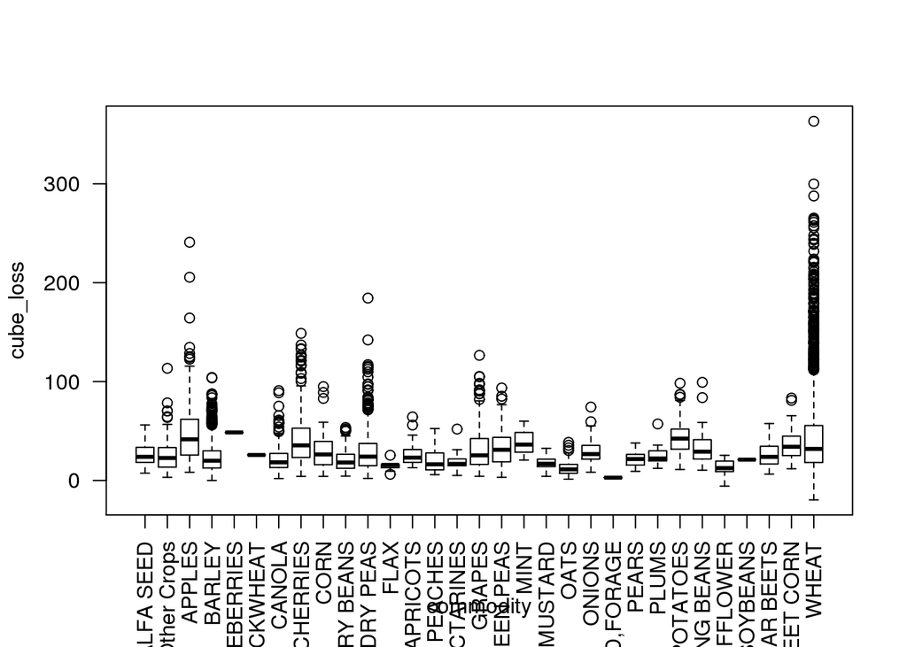

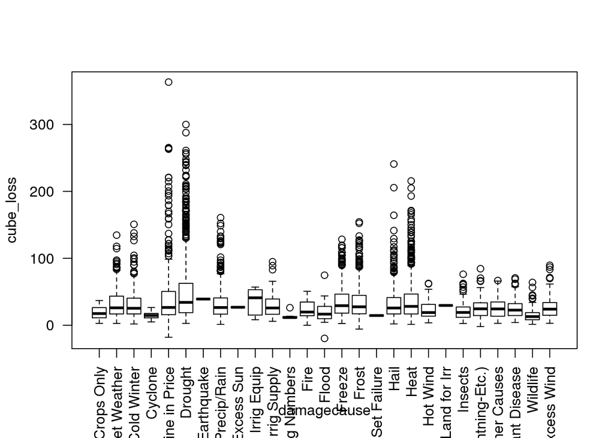

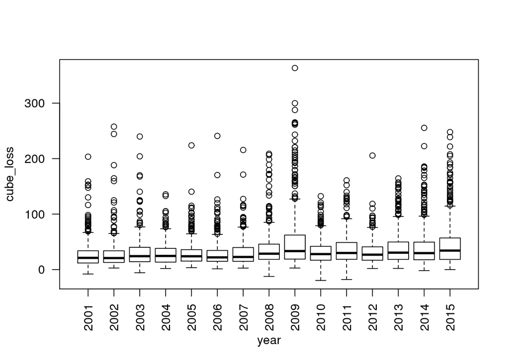

```r
plot(cube_loss ~ county + commodity + damagecause + year, data=palouse_sumloss_allcomm2, las = 2)
```

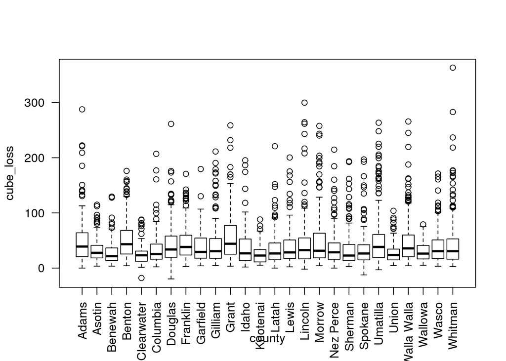

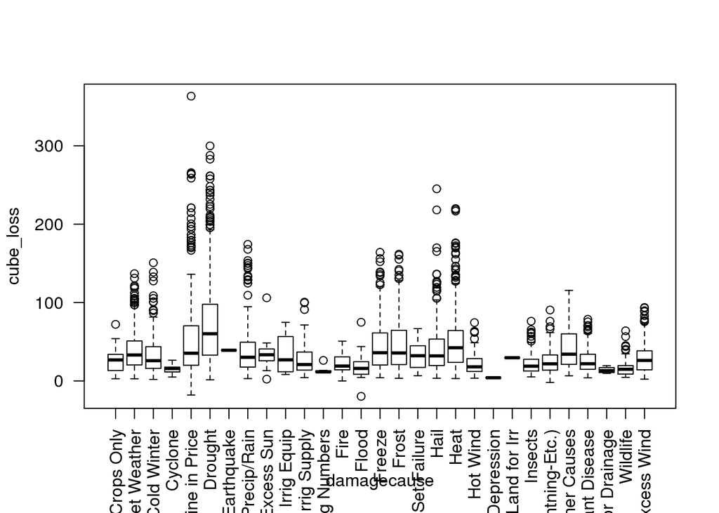

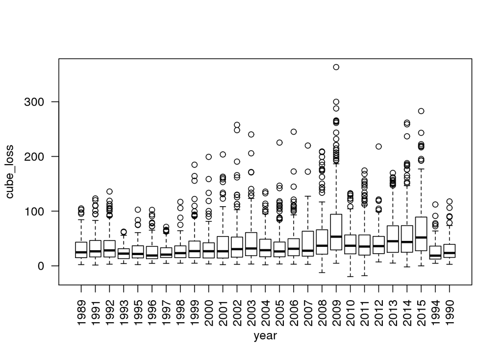

```r
plot(cube_loss ~ county + damagecause + year, data=palouse_sumloss, las = 2)
```